# Data Analytics-IST 707 HW03

In this report we will be analysing the Disease prediction dataset.We are going to create various disease diagnosis models using Logistic Regression, Decision Tree, Artificial Neural Network in order to predict whether the patient has the specific disease.

Submitted by:Jaishree Palaniswamy

#### **Package Loading:**

Load all the required packages:

```r
require(MASS)
library(ggplot2)
library(dplyr)
library(tidyr)
library(tidyverse)
library(klaR)
library(e1071)
library(mlbench)
library(kernlab)
library(recipes)
library(pROC)
library(precrec)
library(keras)
library(tensorflow)
library(yardstick)
library(caret)
library(ROCR)
library(data.table)
```

#### **Data Loading:**

Let us read the training and testing datasets.

```r
cardio_train<-read.csv("C:/Users/ragha/Desktop/Priya/Disease Prediction Training.csv", header=TRUE)
cardio_test<-read.csv("C:/Users/ragha/Desktop/Priya/Disease Prediction Testing.csv", header=TRUE)
```

#### **Data Exploration:**

```r
str(cardio_train)
```

```
## 'data.frame':    49000 obs. of  12 variables:
##  $ Age                : int  59 64 41 50 39 54 48 51 42 41 ...
##  $ Gender             : chr  "female" "female" "female" "male" ...
##  $ Height             : int  167 150 166 172 162 163 159 171 161 159 ...
##  $ Weight             : num  88 71 83 110 61 61 89 71 72 43 ...
##  $ High.Blood.Pressure: int  130 140 100 130 110 120 150 110 150 90 ...
##  $ Low.Blood.Pressure : int  68 100 70 80 80 80 90 70 90 60 ...
##  $ Cholesterol        : chr  "normal" "normal" "normal" "normal" ...
##  $ Glucose            : chr  "normal" "normal" "normal" "normal" ...
##  $ Smoke              : int  0 0 0 1 0 0 0 0 0 0 ...
##  $ Alcohol            : int  0 0 1 0 0 0 0 0 0 0 ...
##  $ Exercise           : int  1 0 1 1 1 1 1 1 1 1 ...
##  $ Disease            : int  0 1 0 0 0 0 1 0 1 0 ...
```

```r
summary(cardio_train)
```

```
##       Age           Gender              Height          Weight
##  Min.   :29.00   Length:49000       Min.   : 55.0   Min.   : 10.00
##  1st Qu.:48.00   Class :character   1st Qu.:159.0   1st Qu.: 65.00
##  Median :53.00   Mode  :character   Median :165.0   Median : 72.00
##  Mean   :52.85                      Mean   :164.4   Mean   : 74.19
##  3rd Qu.:58.00                      3rd Qu.:170.0   3rd Qu.: 82.00
##  Max.   :64.00                      Max.   :207.0   Max.   :200.00
##  High.Blood.Pressure Low.Blood.Pressure Cholesterol          Glucose
##  Min.   : -150.0     Min.   :    0.00   Length:49000       Length:49000
##  1st Qu.:  120.0     1st Qu.:   80.00   Class :character   Class :character
##  Median :  120.0     Median :   80.00   Mode  :character   Mode  :character
##  Mean   :  128.7     Mean   :   96.92
##  3rd Qu.:  140.0     3rd Qu.:   90.00
##  Max.   :14020.0     Max.   :11000.00
##      Smoke            Alcohol           Exercise         Disease
##  Min.   :0.00000   Min.   :0.00000   Min.   :0.0000   Min.   :0.0
##  1st Qu.:0.00000   1st Qu.:0.00000   1st Qu.:1.0000   1st Qu.:0.0
##  Median :0.00000   Median :0.00000   Median :1.0000   Median :0.0
##  Mean   :0.08827   Mean   :0.05424   Mean   :0.8032   Mean   :0.5
##  3rd Qu.:0.00000   3rd Qu.:0.00000   3rd Qu.:1.0000   3rd Qu.:1.0
##  Max.   :1.00000   Max.   :1.00000   Max.   :1.0000   Max.   :1.0
```

NA values:

```r
sapply(cardio_train, function(x) sum(is.na(x)))
```

```
##                 Age              Gender              Height              Weight
##                   0                   0                   0                   0
## High.Blood.Pressure  Low.Blood.Pressure         Cholesterol             Glucose
##                   0                   0                   0                   0
##               Smoke             Alcohol            Exercise             Disease
##                   0                   0                   0                   0
```

Since there are no NA’s in the dataset, we can move further with our analysis.

Removing the duplicate values from the dataset:

```r
cardio_train<-cardio_train[!duplicated(cardio_train),]
```

Handling the Outliers & Data Visualization:

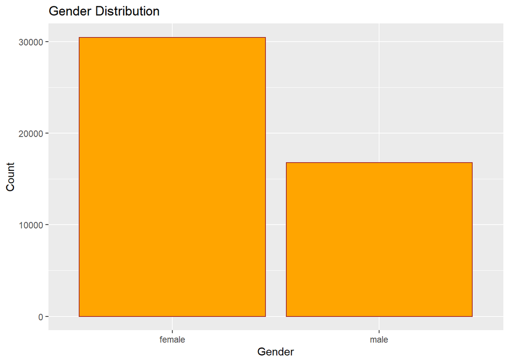

```r
ggplot(cardio_train,aes(x = Gender))+
  geom_bar(fill="orange",color="brown")+
  xlab("Gender")+
  ylab("Count")+
  ggtitle("Gender Distribution")
```

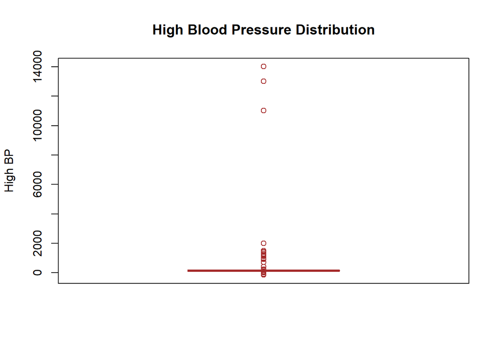

```r
boxplot(cardio_train$High.Blood.Pressure,
main = "High Blood Pressure Distribution",
ylab="High BP",
border = "brown",
vertical = TRUE
)
```

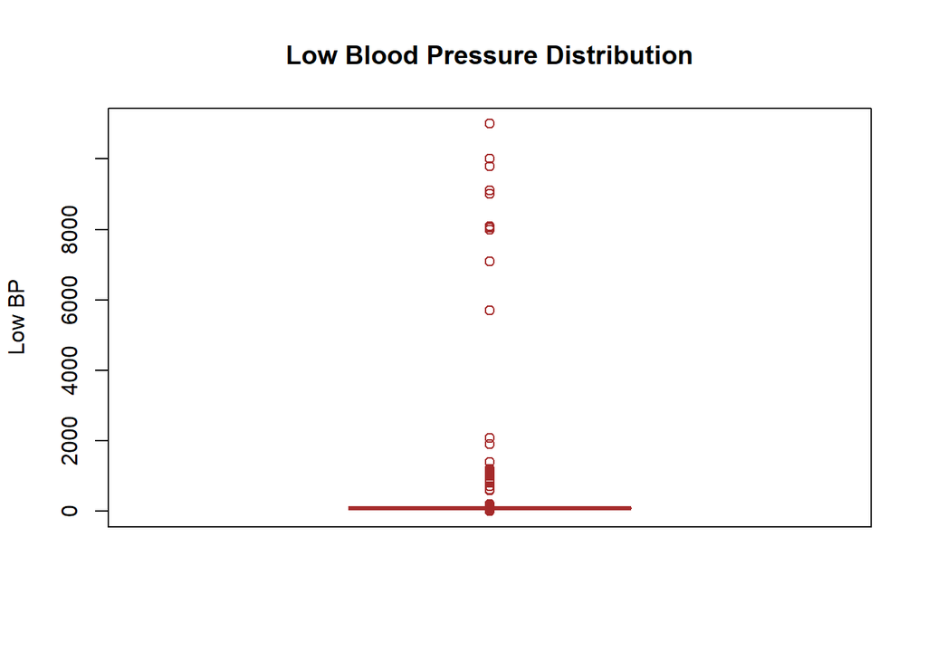

```r
boxplot(cardio_train$Low.Blood.Pressure,
main = "Low Blood Pressure Distribution",
ylab="Low BP",
border = "brown",
vertical = TRUE
)
```

From the above charts,there were many outliers in Low BP and High BP columns with values ranging from negatives to several thousands. I have removed the rows of the Low BP and High BP values that makes no sense by limiting it to particular range.I have taken the Low BP range from 20-190 and High BP range from 60-240.

```r
cardio_train <- cardio_train[cardio_train$Low.Blood.Pressure >= 20,]
cardio_train <- cardio_train[cardio_train$Low.Blood.Pressure <= 190,]

cardio_train <- cardio_train[cardio_train$High.Blood.Pressure>= 60,]
cardio_train <- cardio_train[cardio_train$High.Blood.Pressure <= 240,]
```

```r
cardio_train <-  cardio_train[cardio_train$Height >= 100,]
cardio_train <-  cardio_train[cardio_train$Weight >= 20,]
```

Converting the values to numeric data type:

```r
cardio_train$Age<-as.numeric(cardio_train$Age)
cardio_train$Height<-as.numeric(cardio_train$Height)
cardio_train$Weight<-as.numeric(cardio_train$Weight)
cardio_train$Low.Blood.Pressure<-as.numeric(cardio_train$Low.Blood.Pressure)
cardio_train$High.Blood.Pressure<-as.numeric(cardio_train$High.Blood.Pressure)
cardio_train$Smoke<-as.numeric(cardio_train$Smoke)
cardio_train$Alcohol<-as.numeric(cardio_train$Alcohol)
cardio_train$Exercise<-as.numeric(cardio_train$Exercise)
cardio_train$Disease <- as.factor(cardio_train$Disease)
```

#### **Training and Testing Dataset:**

Let us now split this data into train & test:

```r
train_index <- createDataPartition(cardio_train$Disease, p = 0.8, list = FALSE)
data_train <- cardio_train[train_index, ]
data_test <- cardio_train[-train_index, ]
```

#### **Logistic Regression:**

Logistic regression is a basic model that uses a logistic function to model a binary dependent variable.Logistic regression is used in various fields, including machine learning, most medical fields, and social sciences.

Creating the model using the training dataset:

```r
start1 <- Sys.time()
model_glm <- train(Disease ~ ., data = data_train,
                   method = "glm", family = "binomial")
Sys.time() - start1
```

```r
print(model_glm)
```

```
## Generalized Linear Model
##
## 37115 samples
##    11 predictor
##     2 classes: '0', '1'
##
## No pre-processing
## Resampling: Bootstrapped (25 reps)
## Summary of sample sizes: 37115, 37115, 37115, 37115, 37115, 37115, ...
## Resampling results:
##
##   Accuracy   Kappa
##   0.7276596  0.4557656
```

Lets see the summary of the model:

```r
summary(model_glm)
```

```
##
## Call:
## NULL
##
## Deviance Residuals:
##     Min       1Q   Median       3Q      Max
## -3.9812  -0.9242   0.1878   0.9268   2.5494
##
## Coefficients:
##                         Estimate Std. Error z value Pr(>|z|)
## (Intercept)           -1.052e+01  3.347e-01 -31.427  < 2e-16 ***
## Age                    4.983e-02  1.833e-03  27.184  < 2e-16 ***
## Gendermale            -1.846e-02  3.012e-02  -0.613 0.539899
## Height                -3.128e-03  1.808e-03  -1.731 0.083498 .
## Weight                 9.596e-03  9.312e-04  10.304  < 2e-16 ***
## High.Blood.Pressure    5.274e-02  1.155e-03  45.674  < 2e-16 ***
## Low.Blood.Pressure     1.887e-02  1.774e-03  10.633  < 2e-16 ***
## Cholesterolnormal     -4.579e-01  3.662e-02 -12.502  < 2e-16 ***
## `Cholesteroltoo high`  6.390e-01  5.626e-02  11.358  < 2e-16 ***
## Glucosenormal          2.099e-02  4.874e-02   0.431 0.666674
## `Glucosetoo high`     -3.431e-01  6.866e-02  -4.996 5.84e-07 ***
## Smoke                 -1.720e-01  4.648e-02  -3.702 0.000214 ***
## Alcohol               -2.051e-01  5.612e-02  -3.655 0.000258 ***
## Exercise              -1.969e-01  2.949e-02  -6.678 2.42e-11 ***
## ---
## Signif. codes:  0 '***' 0.001 '**' 0.01 '*' 0.05 '.' 0.1 ' ' 1
##
## (Dispersion parameter for binomial family taken to be 1)
##
##     Null deviance: 51448  on 37114  degrees of freedom
## Residual deviance: 41435  on 37101  degrees of freedom
## AIC: 41463
##
## Number of Fisher Scoring iterations: 4
```

Now,lets plot the ROC curve for the model

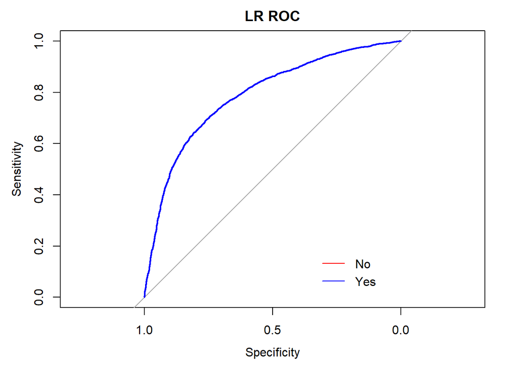

```r
model_glm_prob <- predict(model_glm, newdata = data_test, type = "prob")
roc_curve_glm1 <- roc(data_test$Disease, model_glm_prob[,1])
roc_curve_glm2 <- roc(data_test$Disease, model_glm_prob[,2])
plot(roc_curve_glm1, col = "red", main = "LR ROC")
plot(roc_curve_glm2, col = "blue", add = T)
legend(0.35, 0.2, legend = c("No", "Yes"), lty = 1,
       col=c("red", "blue"), bty = "n")
```

Variable importance of the model:

```r
varImp(model_glm)
```

```
## glm variable importance
##
##                        Overall
## High.Blood.Pressure   100.0000
## Age                    59.1310
## Cholesterolnormal      26.6802
## `Cholesteroltoo high`  24.1512
## Low.Blood.Pressure     22.5491
## Weight                 21.8235
## Exercise               13.8086
## `Glucosetoo high`      10.0912
## Smoke                   7.2293
## Alcohol                 7.1257
## Height                  2.8734
## Gendermale              0.4028
## Glucosenormal           0.0000
```

Let us now go ahead and predict the Disease variable using the above model

```r
predictedlr <- predict(model_glm, data_test)
confusionMatrix(predictedlr, data_test$Disease)
```

```
## Confusion Matrix and Statistics
##
##           Reference
## Prediction    0    1
##          0 3515 1489
##          1 1077 3197
##
##                Accuracy : 0.7234
##                  95% CI : (0.7142, 0.7325)
##     No Information Rate : 0.5051
##     P-Value [Acc > NIR] : < 2.2e-16
##
##                   Kappa : 0.4473
##
##  Mcnemar's Test P-Value : 4.914e-16
##
##             Sensitivity : 0.7655
##             Specificity : 0.6822
##          Pos Pred Value : 0.7024
##          Neg Pred Value : 0.7480
##              Prevalence : 0.4949
##          Detection Rate : 0.3789
##    Detection Prevalence : 0.5393
##       Balanced Accuracy : 0.7239
##
##        'Positive' Class : 0
##
```

```r
head(predictedlr)
```

```
## [1] 0 0 1 0 1 0
## Levels: 0 1
```

#### **Articificial Neural Network:**

An Artificial Neural Network is an information processing model.It is a simple mathematical model of the brain which is used to process nonlinear relationships between inputs and outputs in parallel like a human brain does every second.

Data Preprocessing:

```r
rec_obj <- recipe(Disease ~ ., data = data_train) %>%
  step_dummy(all_nominal(), -all_outcomes()) %>%
   step_center(all_predictors(), -all_outcomes()) %>%
  step_scale(all_predictors(), -all_outcomes()) %>%
  prep(data = data_train)
rec_obj
```

```
## Data Recipe
##
## Inputs:
##
##       role #variables
##    outcome          1
##  predictor         11
##
## Training data contained 37115 data points and no missing data.
##
## Operations:
##
## Dummy variables from Gender, Cholesterol, Glucose [trained]
## Centering for Age, Height, Weight, ... [trained]
## Scaling for Age, Height, Weight, ... [trained]
```

Splitting the dependent and the independent variables in the training and testing datasets

```r
x_train_tbl <- as.matrix(bake(rec_obj, new_data = data_train) %>% select(-Disease))
x_test_tbl <- as.matrix(bake(rec_obj, new_data = data_test) %>% select(-Disease))
y_train_vec <- ifelse(pull(data_train, Disease) == "1", 1, 0)
y_test_vec <-  ifelse(pull(data_test, Disease) == "1", 1, 0)
str(x_train_tbl)
```

```
##  num [1:37115, 1:13] 0.908 1.644 -1.742 -0.417 -0.711 ...
##  - attr(*, "dimnames")=List of 2
##   ..$ : NULL
##   ..$ : chr [1:13] "Age" "Height" "Weight" "High.Blood.Pressure" ...
```

First lets create a model with zero hidden layers and then lets see the performance of the model by adding hidden layers.

ANN0- With zero hidden layer:

```r
start1 <- Sys.time()
model_keras0 <- keras_model_sequential()
model_keras0 %>%
 layer_dense(units = 1, activation = 'sigmoid',input_shape = ncol(x_train_tbl))
head(x_train_tbl)
Sys.time()- start1
```

```r
start1 <- Sys.time()
model_keras0 %>% compile(
  optimizer = 'adam',
  loss = 'binary_crossentropy',
  metrics = c('accuracy')
)
Sys.time()- start1
```

```r
model_keras0
```

```
## Model
## Model: "sequential"
## ________________________________________________________________________________
## Layer (type)                        Output Shape                    Param #
## ================================================================================
## dense (Dense)                       (None, 1)                       14
## ================================================================================
## Total params: 14
## Trainable params: 14
## Non-trainable params: 0
## ________________________________________________________________________________
```

```r
start1 <- Sys.time()
set.seed(100)
fit0 <- model_keras0 %>% fit(x_train_tbl,y_train_vec,epochs = 10)
Sys.time()- start1
```

```
## Time difference of 16.44974 secs
```

Plot training & validation accuracy values

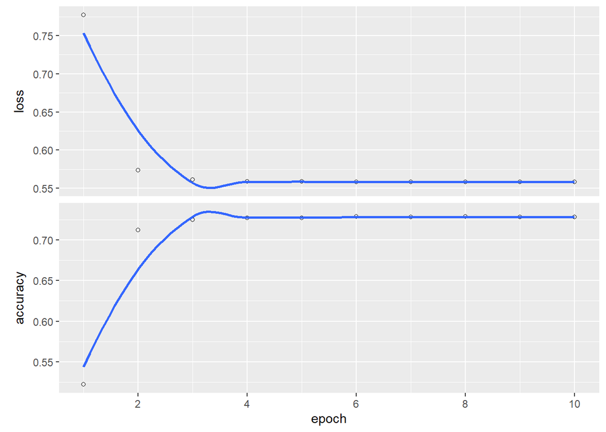

```r
plot(fit0)
```

Predicting the Disease:

```r
disease_pred0 <- model_keras0 %>% predict_classes(x_test_tbl)
disease_pred0[1:20]
```

```
##  [1] 0 0 1 0 1 0 0 0 1 0 0 1 0 0 0 0 1 0 1 0
```

```r
disease_prob0<-model_keras0 %>% predict_proba(x_test_tbl)
```

```r
estimates_keras_tbl0 <- tibble(
  truth = as.factor(y_test_vec) %>% fct_recode(yes = "1", no = "0"),
  estimate = as.factor(disease_pred0) %>% fct_recode(yes = "1", no = "0"),
  class_prob = disease_prob0
)
estimates_keras_tbl0
```

```
## # A tibble: 9,278 x 3
##    truth estimate class_prob[,1]
##    <fct> <fct>             <dbl>
##  1 no    no                0.209
##  2 no    no                0.368
##  3 yes   yes               0.557
##  4 no    no                0.302
##  5 yes   yes               0.600
##  6 no    no                0.142
##  7 yes   no                0.466
##  8 no    no                0.461
##  9 yes   yes               0.987
## 10 no    no                0.307
## # ... with 9,268 more rows
```

Creating the confusion matrix:

```r
options(yardstick.event_first = F)
estimates_keras_tbl0 %>% conf_mat(truth, estimate)
```

```
##           Truth
## Prediction   no  yes
##        no  3509 1483
##        yes 1083 3203
```

Calculating the metrics:

```r
estimates_keras_tbl0 %>% metrics(truth, estimate)
```

```
## # A tibble: 2 x 3
##   .metric  .estimator .estimate
##   <chr>    <chr>          <dbl>
## 1 accuracy binary         0.723
## 2 kap      binary         0.447
```

Precision:

```r
#estimates_keras_tbl0 %>% precision(truth, estimate)
```

Recall:

```r
#estimates_keras_tbl0 %>% recall(truth, estimate)
```

ANN1- With one hidden layer:

```r
model_keras1 <- keras_model_sequential()
model_keras1 %>%
  layer_dense(units = 20, activation = 'relu',input_shape = ncol(x_train_tbl)) %>%
  layer_dense(units = 1, activation = 'sigmoid')
head(x_train_tbl)
```

```r
model_keras1 %>% compile(
  optimizer = 'adam',
  loss = 'binary_crossentropy',
  metrics = c('accuracy')
)
```

```r
set.seed(100)
fit1 <- model_keras1 %>% fit(x_train_tbl,y_train_vec,epochs = 10)
```

Plot training & validation accuracy values

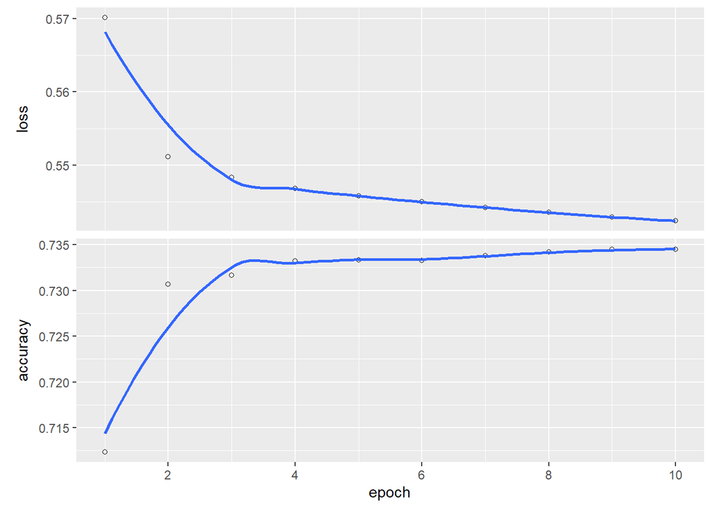

```r
plot(fit1)
```

We can see from the above plot that the accuracy saturates around 73% as the loss continues to drop.

Predicting the Disease:

```r
disease_pred1 <- model_keras1 %>% predict_classes(x_test_tbl)
disease_prob1<-model_keras1 %>% predict_proba(x_test_tbl)
```

```r
estimates_keras_tbl1 <- tibble(
  truth = as.factor(y_test_vec) %>% fct_recode(yes = "1", no = "0"),
  estimate = as.factor(disease_pred1) %>% fct_recode(yes = "1", no = "0"),
  class_prob = disease_prob1
)
estimates_keras_tbl1
```

```
## # A tibble: 9,278 x 3
##    truth estimate class_prob[,1]
##    <fct> <fct>             <dbl>
##  1 no    no                0.169
##  2 no    no                0.316
##  3 yes   yes               0.681
##  4 no    no                0.266
##  5 yes   yes               0.540
##  6 no    no                0.180
##  7 yes   no                0.468
##  8 no    no                0.483
##  9 yes   yes               0.887
## 10 no    no                0.221
## # ... with 9,268 more rows
```

Creating the confusion matrix:

```r
estimates_keras_tbl1 %>% conf_mat(truth, estimate)
```

```
##           Truth
## Prediction   no  yes
##        no  3456 1383
##        yes 1136 3303
```

Calculating the metrics:

```r
estimates_keras_tbl1 %>% metrics(truth, estimate)
```

```
## # A tibble: 2 x 3
##   .metric  .estimator .estimate
##   <chr>    <chr>          <dbl>
## 1 accuracy binary         0.728
## 2 kap      binary         0.457
```

Precision:

```r
#estimates_keras_tbl1 %>% precision(truth, estimate)
```

Recall:

```r
#estimates_keras_tbl1 %>% recall(truth, estimate)
```

ANN2- With two hidden layer:

```r
model_keras2 <- keras_model_sequential()
model_keras2%>%
  #layer_flatten(input_shape = ncol(rec_obj)) %>%
   layer_dense(units = 50, activation = 'relu',input_shape = ncol(x_train_tbl)) %>%
  layer_dense(units = 20, activation = 'relu') %>%
  layer_dense(units = 1, activation = 'sigmoid')
head(x_train_tbl)
```

```r
model_keras2 %>% compile(
  optimizer = 'adam',
  loss = 'binary_crossentropy',
  metrics = c('accuracy')
)
```

```r
set.seed(100)
fit2 <- model_keras2 %>% fit(x_train_tbl,y_train_vec,epochs = 10)
```

Plot training & validation accuracy values

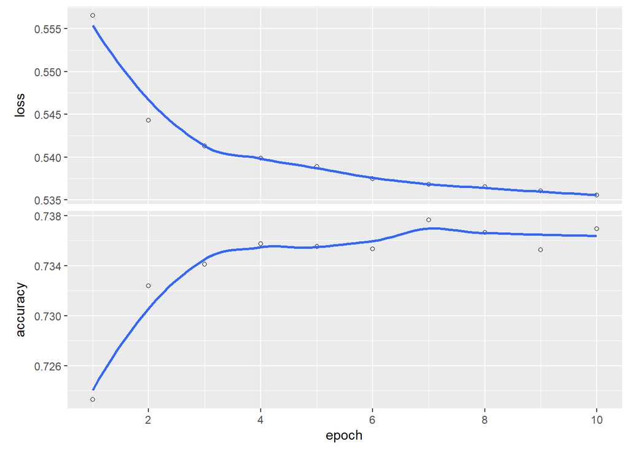

```r
plot(fit2)
```

We can see from the above plot that the accuracy saturates around 73% as the loss continues to drop.

Predicting the Disease:

```r
disease_pred2 <- model_keras2 %>% predict_classes(x_test_tbl)
disease_prob2<-model_keras2 %>% predict_proba(x_test_tbl)
```

```r
estimates_keras_tbl2 <- tibble(
  truth = as.factor(y_test_vec) %>% fct_recode(yes = "1", no = "0"),
  estimate = as.factor(disease_pred2) %>% fct_recode(yes = "1", no = "0"),
  class_prob = disease_prob2
)
estimates_keras_tbl2
```

```
## # A tibble: 9,278 x 3
##    truth estimate class_prob[,1]
##    <fct> <fct>             <dbl>
##  1 no    no                0.148
##  2 no    no                0.296
##  3 yes   yes               0.655
##  4 no    no                0.184
##  5 yes   no                0.481
##  6 no    no                0.132
##  7 yes   no                0.389
##  8 no    yes               0.504
##  9 yes   yes               0.789
## 10 no    no                0.209
## # ... with 9,268 more rows
```

Creating the confusion matrix:

```r
estimates_keras_tbl2 %>% conf_mat(truth, estimate)
```

```
##           Truth
## Prediction   no  yes
##        no  3642 1564
##        yes  950 3122
```

Calculating the metrics:

```r
estimates_keras_tbl2 %>% metrics(truth, estimate)
```

```
## # A tibble: 2 x 3
##   .metric  .estimator .estimate
##   <chr>    <chr>          <dbl>
## 1 accuracy binary         0.729
## 2 kap      binary         0.459
```

Precision:

```r
#estimates_keras_tbl2 %>% precision(truth, estimate)
```

Recall:

```r
#estimates_keras_tbl2 %>% recall(truth, estimate)
```

#### **Decision Tree**

Decision Tree algorithm is a supervised learning algorithms. Unlike other supervised learning algorithms, decision tree algorithm can be used for solving regression and classification problems too.

The general motive of using Decision Tree is to create a training model which can use to predict class or value of target variables by learning decision rules inferred from prior data(training data).

Let us now perform decision tree analysis on this training data.

```r
dt_model <- train(Disease ~ ., data = data_train, metric = "Accuracy", method = "rpart")
```

```r
print(dt_model)
```

```
## CART
##
## 37115 samples
##    11 predictor
##     2 classes: '0', '1'
##
## No pre-processing
## Resampling: Bootstrapped (25 reps)
## Summary of sample sizes: 37115, 37115, 37115, 37115, 37115, 37115, ...
## Resampling results across tuning parameters:
##
##   cp           Accuracy   Kappa
##   0.002259241  0.7245401  0.4494460
##   0.010942349  0.7178853  0.4365692
##   0.419347814  0.6034076  0.2033526
##
## Accuracy was used to select the optimal model using the largest value.
## The final value used for the model was cp = 0.002259241.
```

```r
dt_predict <- predict(dt_model, newdata = data_test, type = "prob")
head(dt_predict, 5)
```

```
##            0         1
## 5  0.7866746 0.2133254
## 6  0.6107428 0.3892572
## 12 0.2389169 0.7610831
## 14 0.7866746 0.2133254
## 19 0.2389169 0.7610831
```

Data Tuning:

```r
start1 <- Sys.time()
model_dt <- train(Disease ~ ., data = data_train, method = "rpart",
                       metric = "Accuracy",
                       tuneLength = 25,
                       trControl = trainControl(method = "repeatedcv", number = 10, repeats = 3))
Sys.time() - start1
```

```
## Time difference of 17.18208 secs
```

Predict the Disease with the tuned model:

```r
predict_dt <- predict(model_dt, newdata = data_test, type = "raw")
confusionMatrix(predict_dt, data_test$Disease)
```

```
## Confusion Matrix and Statistics
##
##           Reference
## Prediction    0    1
##          0 3503 1413
##          1 1089 3273
##
##                Accuracy : 0.7303
##                  95% CI : (0.7212, 0.7393)
##     No Information Rate : 0.5051
##     P-Value [Acc > NIR] : < 2.2e-16
##
##                   Kappa : 0.461
##
##  Mcnemar's Test P-Value : 1.065e-10
##
##             Sensitivity : 0.7628
##             Specificity : 0.6985
##          Pos Pred Value : 0.7126
##          Neg Pred Value : 0.7503
##              Prevalence : 0.4949
##          Detection Rate : 0.3776
##    Detection Prevalence : 0.5299
##       Balanced Accuracy : 0.7307
##
##        'Positive' Class : 0
##
```

Plot the ROC curve of the model:

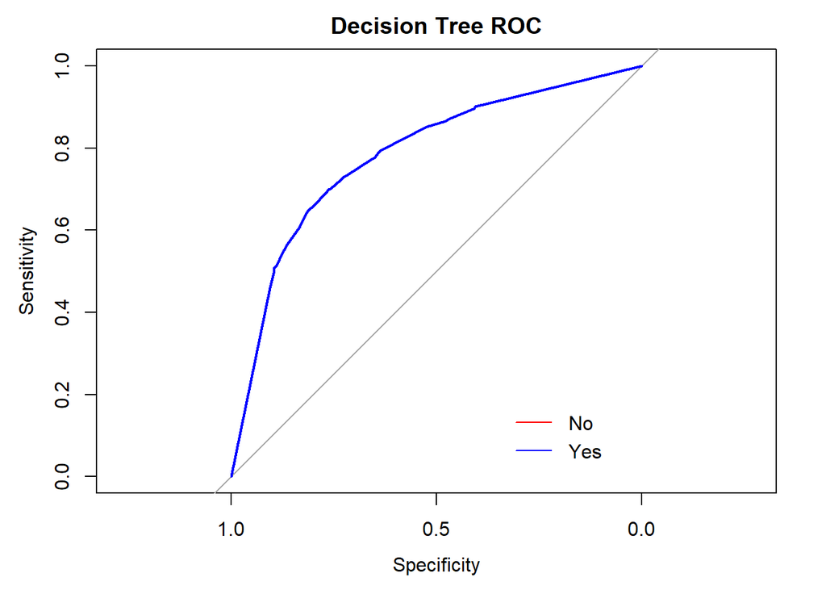

```r
dt_pred_prob <- predict(model_dt, newdata = data_test, type = "prob")
roc_curve1 <- roc(data_test$Disease, dt_pred_prob[,1])
roc_curve2 <- roc(data_test$Disease, dt_pred_prob[,2])
plot(roc_curve1, col = "red", main = "Decision Tree ROC")
plot(roc_curve2, col = "blue", add = T)
legend(0.35, 0.2, legend = c("No", "Yes"), lty = 1,
       col=c("red", "blue"), bty = "n")
```

#### **Models for Comparison**

#### **Random Forest**

Random Forest algorithm can be used for both regression and classification problems. Two methods for tuning the model for, 1. Random Search and 2. Grid Search

Grid Search: In grid search the model is evaluated with all the combinations that are passed in the function, using cross-validation

Random Search: Unlike grid search, random search will not evaluate all the combinations of hyperparameters, instead a random combination is chosen at every iteration.

For tuning, let us use grid search.

Default setting:

```r
trControl <- trainControl(method = "cv",
                          number = 3,
                          search = "grid")
```

```r
set.seed(1234)
# Run the model
default_rf_model <- train(Disease~.,
                          data = data_train,
                          method = "rf",
                          metric = "Accuracy",
                          trControl = trControl)
```

Let us test the values of mtry from 1 to 10

```r
set.seed(1234)
tuneGrid <- expand.grid(.mtry = c(1:10))
```

Let us train the random forest model with the parameters.

```r
start1 <- Sys.time()
fit_rf <- train(Disease~.,
                data_train,
                method = "rf",
                metric = "Accuracy",
                tuneGrid = tuneGrid,
                trControl = trControl,
                importance = TRUE,
                nodesize = 25,
                ntree = 350,
                maxnodes = 30)
Sys.time()-start1
```

```
## Time difference of 5.303445 mins
```

Let us predict the disease on test data set

```r
prediction <-predict(fit_rf, data_test)
```

Checking for the accuracy

```r
confusionMatrix(prediction, data_test$Disease)
```

```
## Confusion Matrix and Statistics
##
##           Reference
## Prediction    0    1
##          0 3588 1501
##          1 1004 3185
##
##                Accuracy : 0.73
##                  95% CI : (0.7208, 0.739)
##     No Information Rate : 0.5051
##     P-Value [Acc > NIR] : < 2.2e-16
##
##                   Kappa : 0.4605
##
##  Mcnemar's Test P-Value : < 2.2e-16
##
##             Sensitivity : 0.7814
##             Specificity : 0.6797
##          Pos Pred Value : 0.7051
##          Neg Pred Value : 0.7603
##              Prevalence : 0.4949
##          Detection Rate : 0.3867
##    Detection Prevalence : 0.5485
##       Balanced Accuracy : 0.7305
##
##        'Positive' Class : 0
##
```

#### **Support Vector Machine**

A Support Vector Machine (SVM) is a supervised machine learning algorithm that can be employed for both classification and regression purposes. SVMs are more commonly used in classification problems. So, lets go ahead and train the model on the trianing data:

Linear Model:

```r
start1 <- Sys.time()
model_svm_linear <- train(Disease ~ ., data = data_train,
                          method = "svmLinear",
                          preProcess = c("center", "scale"),
                          trControl = trainControl(method = "cv", number = 3),
                          tuneGrid = expand.grid(C = seq(0, 1, 0.05)))
Sys.time()-start1
```

```
## Time difference of 22.52823 mins
```

Lets have a look at the model:

```r
model_svm_linear
```

```
## Support Vector Machines with Linear Kernel
##
## 37115 samples
##    11 predictor
##     2 classes: '0', '1'
##
## Pre-processing: centered (13), scaled (13)
## Resampling: Cross-Validated (3 fold)
## Summary of sample sizes: 24743, 24744, 24743
## Resampling results across tuning parameters:
##
##   C     Accuracy   Kappa
##   0.00        NaN        NaN
##   0.05  0.7271722  0.4551634
##   0.10  0.7272530  0.4553251
##   0.15  0.7273877  0.4555950
##   0.20  0.7273338  0.4554868
##   0.25  0.7273069  0.4554333
##   0.30  0.7273338  0.4554868
##   0.35  0.7273608  0.4555403
##   0.40  0.7273608  0.4555397
##   0.45  0.7273608  0.4555397
##   0.50  0.7273608  0.4555397
##   0.55  0.7274147  0.4556461
##   0.60  0.7274147  0.4556473
##   0.65  0.7274416  0.4557008
##   0.70  0.7274147  0.4556473
##   0.75  0.7273877  0.4555926
##   0.80  0.7273877  0.4555932
##   0.85  0.7273877  0.4555932
##   0.90  0.7273877  0.4555926
##   0.95  0.7273877  0.4555932
##   1.00  0.7273877  0.4555938
##
## Accuracy was used to select the optimal model using the largest value.
## The final value used for the model was C = 0.65.
```

Lets predict the disease on test data set

```r
predict_svm_linear <- predict(model_svm_linear, newdata = data_test)
```

Checking the accuracy of the model

```r
confusionMatrix(predict_svm_linear, data_test$Disease)
```

```
## Confusion Matrix and Statistics
##
##           Reference
## Prediction    0    1
##          0 3663 1625
##          1  929 3061
##
##                Accuracy : 0.7247
##                  95% CI : (0.7155, 0.7338)
##     No Information Rate : 0.5051
##     P-Value [Acc > NIR] : < 2.2e-16
##
##                   Kappa : 0.4502
##
##  Mcnemar's Test P-Value : < 2.2e-16
##
##             Sensitivity : 0.7977
##             Specificity : 0.6532
##          Pos Pred Value : 0.6927
##          Neg Pred Value : 0.7672
##              Prevalence : 0.4949
##          Detection Rate : 0.3948
##    Detection Prevalence : 0.5700
##       Balanced Accuracy : 0.7255
##
##        'Positive' Class : 0
##
```

#### **GBM**

GBM is a machine learning technique for regression and classification problems. It builds the model in a stage-wise fashion like other boosting methods do, and it generalizes them by allowing optimization of an arbitrary differentiable loss function.

```r
start1 <- Sys.time()

set.seed(825)
gbmFit1 <- train(Disease ~ ., data = data_train,
                 method = "gbm",
                 trControl = trainControl(method = "cv", number = 3),
                 verbose = FALSE)
gbmFit1
```

```
## Stochastic Gradient Boosting
##
## 37115 samples
##    11 predictor
##     2 classes: '0', '1'
##
## No pre-processing
## Resampling: Cross-Validated (3 fold)
## Summary of sample sizes: 24743, 24743, 24744
## Resampling results across tuning parameters:
##
##   interaction.depth  n.trees  Accuracy   Kappa
##   1                   50      0.7220530  0.4449227
##   1                  100      0.7255556  0.4518403
##   1                  150      0.7290852  0.4588360
##   2                   50      0.7279535  0.4564853
##   2                  100      0.7304862  0.4614111
##   2                  150      0.7331536  0.4666668
##   3                   50      0.7307286  0.4618176
##   3                  100      0.7326955  0.4657103
##   3                  150      0.7335038  0.4672872
##
## Tuning parameter 'shrinkage' was held constant at a value of 0.1
##
## Tuning parameter 'n.minobsinnode' was held constant at a value of 10
## Accuracy was used to select the optimal model using the largest value.
## The final values used for the model were n.trees = 150, interaction.depth =
##  3, shrinkage = 0.1 and n.minobsinnode = 10.
```

```r
Sys.time()-start1
```

```
## Time difference of 22.32078 secs
```

Lets predict the disease

```r
prediction_gbm_tuned <-predict(gbmFit1, data_test)
```

Check for accuracy

```r
confusionMatrix(prediction_gbm_tuned, data_test$Disease)
```

```
## Confusion Matrix and Statistics
##
##           Reference
## Prediction    0    1
##          0 3491 1398
##          1 1101 3288
##
##                Accuracy : 0.7307
##                  95% CI : (0.7215, 0.7397)
##     No Information Rate : 0.5051
##     P-Value [Acc > NIR] : < 2.2e-16
##
##                   Kappa : 0.4616
##
##  Mcnemar's Test P-Value : 3.196e-09
##
##             Sensitivity : 0.7602
##             Specificity : 0.7017
##          Pos Pred Value : 0.7141
##          Neg Pred Value : 0.7491
##              Prevalence : 0.4949
##          Detection Rate : 0.3763
##    Detection Prevalence : 0.5269
##       Balanced Accuracy : 0.7309
##
##        'Positive' Class : 0
##
```

Comparison of all the models:

```r
master_table= data.table(
  Models=c("DT","ANN2","GBM","ANN1","RF","LR","ANN0","SVMNL","SVML","KNN","NBC"),
  Accuracy=c(0.7364,0.7359,0.7352,0.7334,0.731,0.7303,0.7298,0.7281,0.7272, 0.715,0.7085),
  Recall=c(0.7779,0.687,0.7644,0.7025,0.7729,0.7777,0.6869,0.7715,0.8027,0.7420,0.8451),
  Precision=c(0.7147,0.766,0.7185,0.7559,0.7095,0.7068,0.7558,0.7068,0.6939,0.7007,0.6611),
  Approx.Time=c(16.85,62.678,20.70,32.67,297,6.65,22.54,1190.5,1172.4,733.2,291.6)


)
master_table
```

[output not shown]

[output not shown]

##### **Testing Data Exploration**

```r
sapply(cardio_test, function(x) sum(is.na(x)))
```

```
##                  ID                 Age              Gender              Height
##                   0                   0                   0                   0
##              Weight High.Blood.Pressure  Low.Blood.Pressure         Cholesterol
##                   0                   0                   0                   0
##             Glucose               Smoke             Alcohol            Exercise
##                   0                   0                   0                   0
```

```r
cardio_test<-cardio_test[!duplicated(cardio_test),]
cardio_test<- cardio_test[cardio_test$Low.Blood.Pressure >= 20,]
cardio_test <-  cardio_test[cardio_test$Low.Blood.Pressure <= 190,]
cardio_test <-  cardio_test[cardio_test$High.Blood.Pressure>= 60,]
cardio_test <-  cardio_test[cardio_test$High.Blood.Pressure <= 240,]
cardio_test <-  cardio_test[cardio_test$Height >= 100,]
cardio_test <-  cardio_test[cardio_test$Weight >= 20,]
```

```r
cardio_test$Weight<-as.numeric(cardio_test$Weight)
cardio_test$Age<-as.numeric(cardio_test$Age)
cardio_test$Height<-as.numeric(cardio_test$Height)
cardio_test$Low.Blood.Pressure<-as.numeric(cardio_test$Low.Blood.Pressure)
cardio_test$High.Blood.Pressure<-as.numeric(cardio_test$High.Blood.Pressure)
cardio_test$Smoke<-as.numeric(cardio_test$Smoke)
cardio_test$Alcohol<-as.numeric(cardio_test$Alcohol)
cardio_test$Exercise<-as.numeric(cardio_test$Exercise)
```

```r
str(cardio_test)
```

```
## 'data.frame':    20623 obs. of  12 variables:
##  $ ID                 : int  0 1 2 3 4 5 6 7 8 9 ...
##  $ Age                : num  44 41 63 55 55 58 45 52 58 52 ...
##  $ Gender             : chr  "female" "female" "male" "female" ...
##  $ Height             : num  160 169 168 158 167 162 161 149 168 165 ...
##  $ Weight             : num  59 74 84 108 67 95 68 85 64 92 ...
##  $ High.Blood.Pressure: num  100 120 120 160 120 130 120 160 140 150 ...
##  $ Low.Blood.Pressure : num  80 70 80 100 80 70 70 90 90 100 ...
##  $ Cholesterol        : chr  "high" "normal" "normal" "normal" ...
##  $ Glucose            : chr  "normal" "normal" "high" "normal" ...
##  $ Smoke              : num  0 0 0 0 0 0 0 0 0 0 ...
##  $ Alcohol            : num  0 0 0 0 0 0 0 0 0 0 ...
##  $ Exercise           : num  1 1 1 0 1 1 1 1 1 1 ...
```

For ANN Model:

```r
rec_obj1<- recipe(ID ~ ., data = cardio_test) %>%
  step_dummy(all_nominal(), -all_outcomes()) %>%
   step_center(all_predictors(), -all_outcomes()) %>%
  step_scale(all_predictors(), -all_outcomes()) %>%
  prep(data = cardio_test)
rec_obj1
```

```
## Data Recipe
##
## Inputs:
##
##       role #variables
##    outcome          1
##  predictor         11
##
## Training data contained 20623 data points and no missing data.
##
## Operations:
##
## Dummy variables from Gender, Cholesterol, Glucose [trained]
## Centering for Age, Height, Weight, ... [trained]
## Scaling for Age, Height, Weight, ... [trained]
```

```r
y_test_tbl <- as.matrix(bake(rec_obj1, new_data = cardio_test) %>% select(-ID))
```

```r
LR <- predict(model_glm, newdata = cardio_test)
ANN0 <- model_keras0 %>% predict_classes(y_test_tbl)
ANN1<-model_keras1 %>% predict_classes(y_test_tbl)
ANN2<-model_keras2 %>% predict_classes(y_test_tbl)
DT<-predict(model_dt,newdata=cardio_test)
```

Now lets create a data frame in which we can store the prediction of the each model and also include an ID column.

```r
finalResults<-data.frame(LR=LR,ANN0=ANN0,ANN1=ANN1,ANN2=ANN2,DT=DT)
finalResults["ID"]<-seq.int(nrow(finalResults))
```

```r
write.csv(finalResults, file="C:/Users/ragha/Desktop/Priya/finalResults.csv",
          row.names=FALSE)
```